# Baseball Data Analysis

Author: Bo Liu Date: 23 Jul 2017

## Summary

This is about exploring baseball data in Python.

The dataset is Baseball Data - A data set containing complete batting and pitching statistics from 1871 to 2014, plus fielding statistics, standings, team stats, managerial records, post-season data, and more.

## Questions

We care about the following two questions:

1. What make players more likely to be voted into Hall of Fame.
2. What are the characteristics of baseball players with the highest salaries?

To solve those questions first make it more specific as follow:

1. What’s the relationship of batting, pitching and fielding statistics and Hall of Fame members?
2. What’s the relationship of Hall of Fame members, All-star player, awards, and salary?

## Loading Data

Downloading data from [this link](http://seanlahman.com/files/database/baseballdatabank-2017.1.zip).

This dataset contains 28 csv including pitching, hitting, and fielding statistics for Major League Baseball from 1871 through 2016. It includes data from the two current leagues (American and National), the four other “major” leagues (American Association, Union Association, Players League, and Federal League), and the National Association of 1871-1875.

More details are in the [readme file](http://seanlahman.com/files/database/readme2016.txt).

To answer those two questions, we only need some of those files including Master, AllStarFull, HallofFame, AwardsPlayers, Salaries, Batting, Pitching, Fielding.

```python
import pandas as pd
import numpy as np
import matplotlib.pyplot as plt
from __future__ import division
```

```python
# read csv files
def read_csv(filename):
    path =  './baseballdatabank-2017.1/core/'
    return pd.read_csv(path+filename)

# load files that relevent to our questions
Players = read_csv('Master.csv')
Allstar = read_csv('AllstarFull.csv')
Awards = read_csv('AwardsPlayers.csv')
Batting = read_csv('Batting.csv')
Fielding = read_csv('Fielding.csv')
HallOfFame = read_csv('HallOfFame.csv')
Pitching = read_csv('Pitching.csv')
Salaries = read_csv('Salaries.csv')
```

## Investigating the Data

First have a look at the size of dataset.

```python
Players.shape
```

```
(19105, 24)
```

```python
Players.head()
```

|  | playerID | birthYear | birthMonth | birthDay | birthCountry | birthState | birthCity | deathYear | deathMonth | deathDay | ... | nameLast | nameGiven | weight | height | bats | throws | debut | finalGame | retroID | bbrefID |
| --- | --- | --- | --- | --- | --- | --- | --- | --- | --- | --- | --- | --- | --- | --- | --- | --- | --- | --- | --- | --- | --- |
| 0 | aardsda01 | 1981.0 | 12.0 | 27.0 | USA | CO | Denver | NaN | NaN | NaN | ... | Aardsma | David Allan | 215.0 | 75.0 | R | R | 2004-04-06 | 2015-08-23 | aardd001 | aardsda01 |
| 1 | aaronha01 | 1934.0 | 2.0 | 5.0 | USA | AL | Mobile | NaN | NaN | NaN | ... | Aaron | Henry Louis | 180.0 | 72.0 | R | R | 1954-04-13 | 1976-10-03 | aaroh101 | aaronha01 |
| 2 | aaronto01 | 1939.0 | 8.0 | 5.0 | USA | AL | Mobile | 1984.0 | 8.0 | 16.0 | ... | Aaron | Tommie Lee | 190.0 | 75.0 | R | R | 1962-04-10 | 1971-09-26 | aarot101 | aaronto01 |
| 3 | aasedo01 | 1954.0 | 9.0 | 8.0 | USA | CA | Orange | NaN | NaN | NaN | ... | Aase | Donald William | 190.0 | 75.0 | R | R | 1977-07-26 | 1990-10-03 | aased001 | aasedo01 |
| 4 | abadan01 | 1972.0 | 8.0 | 25.0 | USA | FL | Palm Beach | NaN | NaN | NaN | ... | Abad | Fausto Andres | 184.0 | 73.0 | L | L | 2001-09-10 | 2006-04-13 | abada001 | abadan01 |

5 rows × 24 columns

We have 19105 rows and 24 columns, but only some of them are Hall of Fame plyers. So Let's find out how many playres in Hall of Fame.

```python
HallOfFame_players = HallOfFame.playerID.unique()
Allstar_players = Allstar.playerID.unique()
Awards_players = Awards.playerID.unique()
```

To anylysis the relationship between batting, pitching, fielding statistcs and Players voted into Hall of Fame, we have to choose typical feature in each of those sporting data.We choose H in Batting and Pitching which reprsents hits in a game. And choose A in fielding data which represents Assists in a game.

Since put all those corresponding variables in one dataframe is convenient for our analysis, let's do subsetting and mergging.

```python
new_batting = {'playerID':Batting['playerID'],'H_batting' : Batting['H']}
new_pitching = {'playerID': Pitching['playerID'],'H_pitching': Pitching['H']}
new_fielding = {'playerID': Fielding['playerID'],'Assists': Fielding['A']}
new_batting = pd.DataFrame(new_batting)
new_pitching = pd.DataFrame(new_pitching)
new_fielding = pd.DataFrame(new_fielding)

new_df = new_batting.merge(new_pitching, on='playerID', how='inner')
new_df = new_df.merge(new_fielding,on='playerID', how='inner')
```

Now we have a new dataframe that contains all the elements we need.

```python
new_df.head()
```

|  | H_batting | playerID | H_pitching | Assists |
| --- | --- | --- | --- | --- |
| 0 | 44 | allisdo01 | 11 | 15.0 |
| 1 | 44 | allisdo01 | 11 | 23.0 |
| 2 | 44 | allisdo01 | 11 | 2.0 |
| 3 | 44 | allisdo01 | 11 | 8.0 |
| 4 | 44 | allisdo01 | 11 | 17.0 |

Check out statistical data betwen Hall of Fame players and Non-Hall of Fame players.

```python
new_df['is_HOF'] = new_df['playerID'].isin(HallOfFame_players)

new_df.groupby('is_HOF').describe()['Assists']
new_df.groupby('is_HOF').describe()['H_batting']
new_df.groupby('is_HOF').describe()['H_pitching']
```

| is_HOF | count | mean | std | min | 25% | 50% | 75% | max |
| --- | --- | --- | --- | --- | --- | --- | --- | --- |
| False | 3816068.0 | 96.309563 | 87.901406 | 0.0 | 27.0 | 67.0 | 153.0 | 772.0 |
| True | 2218411.0 | 141.576206 | 99.768692 | 0.0 | 54.0 | 137.0 | 219.0 | 753.0 |

Finally, create plots to show our findings, this part refered to [this](http://blog.bharatbhole.com/creating-boxplots-with-matplotlib/) article.

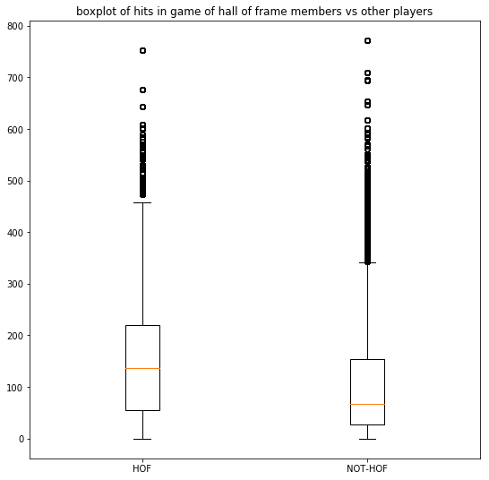

```python
collectn_1 = new_df.loc[new_df.is_HOF==True, 'H_pitching']
collectn_2 = new_df.loc[new_df.is_HOF==False, 'H_pitching']

data_to_plot = [collectn_1,collectn_2]
# Create a figure instance
fig = plt.figure(1,figsize=(9, 9))

# Create an axes instance
ax = fig.add_subplot(111)

# Create the boxplot
bp=ax.boxplot(data_to_plot)
ax.set_title('boxplot of hits in game of hall of frame members vs other players')
ax.set_xticklabels(['HOF', 'NOT-HOF'])
plt.show()
```

### What’s the relationship of Hall of Fame members, All-star player, awards, and salary?

#### salary and body data

Creat salaries dataframe.

```python
df_salaries = {'playerID':Salaries['playerID'],'salary' : Salaries['salary']}
df_salaries = pd.DataFrame(df_salaries)
```

Show distribution of salaries.

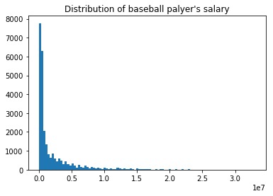

```python
plt.hist(df_salaries.salary,bins = 100)
plt.title('Distribution of baseball palyer\'s salary')
plt.show()
```

Get top 0.3% high salaries.

```python
sort_salaries = df_salaries.salary.sort_values(ascending=False)
index_top = int(round(len(sort_salaries)*0.003))
df_top_salaries = sort_salaries.iloc[0:index_top]
df_top_salaries = pd.DataFrame(df_top_salaries)
```

Merge weight and height data to salary dataframe. Add a column indicating which player is in the top 0.3% club.

```python
df_wt_ht = {'playerID':Players['playerID'],
               'weight' : Players['weight'],
               'height':Players['height']}
df_wt_ht  = pd.DataFrame(df_wt_ht)

df_wt_ht = df_wt_ht.merge(df_salaries, on='playerID', how='inner')

df_wt_ht['is_top'] = df_wt_ht.salary.isin(df_top_salaries.salary)
df_wt_ht.head()
```

|  | height | playerID | weight | salary | is_top |
| --- | --- | --- | --- | --- | --- |
| 0 | 75.0 | aardsda01 | 215.0 | 300000 | False |
| 1 | 75.0 | aardsda01 | 215.0 | 387500 | False |
| 2 | 75.0 | aardsda01 | 215.0 | 403250 | False |
| 3 | 75.0 | aardsda01 | 215.0 | 419000 | False |
| 4 | 75.0 | aardsda01 | 215.0 | 2750000 | False |

Now make a scatter plot to find out if there are any patterns between high salaries and height and weight.

First look at the distribution of all players.

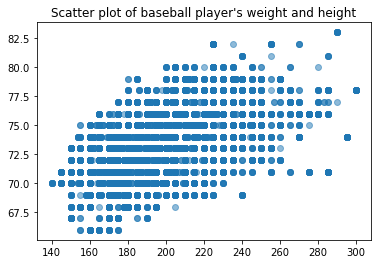

```python
plt.scatter(df_wt_ht.weight, df_wt_ht.height,alpha=0.5)
plt.title('Scatter plot of baseball player\'s weight and height')
plt.show()
```

Make another scatter plot to show the top 0.3% salary players.

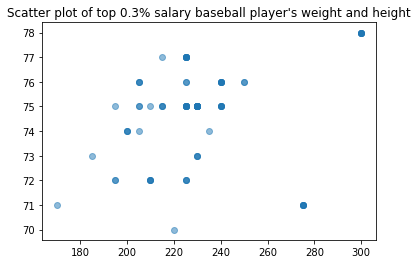

```python
df_wt_ht[df_wt_ht.is_top == True].weight

plt.scatter(df_wt_ht[df_wt_ht.is_top == True].weight,
            df_wt_ht[df_wt_ht.is_top == True].height,
            alpha=0.5)
plt.title('Scatter plot of top 0.3% salary baseball player\'s weight and height')
plt.show()
```

This plot show that high salary players tend to have around 220 weight.

Let's see the statistical data to prove our theory.

```python
df_wt_ht.groupby(['is_top']).describe()
```

| is_top | height count | height mean | height std | height min | height 25% | height 50% | height 75% | height max | salary count | salary mean | salary ... | salary 75% | salary max | weight count | weight mean | weight std | weight min | weight 25% | weight 50% | weight 75% | weight max |
| --- | --- | --- | --- | --- | --- | --- | --- | --- | --- | --- | --- | --- | --- | --- | --- | --- | --- | --- | --- | --- | --- |
| False | 26333.0 | 73.504310 | 2.285727 | 66.0 | 72.0 | 74.0 | 75.0 | 83.0 | 26333.0 | 2.009846e+06 | ... | 2300000.0 | 21857143.0 | 26333.0 | 198.901378 | 22.499818 | 140.0 | 185.0 | 195.0 | 215.0 | 300.0 |
| True | 87.0 | 74.770115 | 1.933193 | 70.0 | 74.0 | 75.0 | 76.0 | 78.0 | 87.0 | 2.446449e+07 | ... | 25000000.0 | 33000000.0 | 87.0 | 230.804598 | 26.565776 | 170.0 | 215.0 | 225.0 | 240.0 | 300.0 |

2 rows × 24 columns

Players with high salary have average 230.80 weight which is more than the average weight of other palyers which is 198.90. So it seems that high salary players are heavier than other players.

#### salary and Hall of Fame

This time we care about Hall of Fame players.

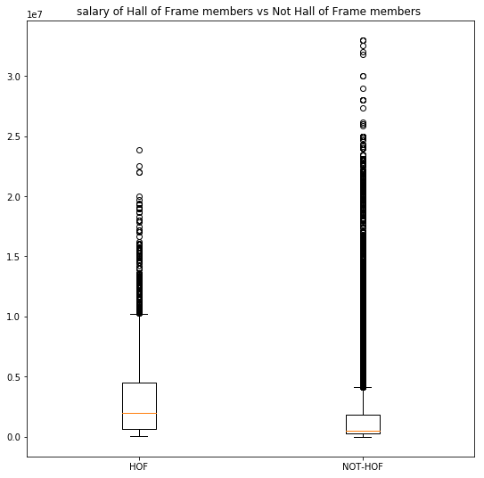

```python
collectn_3 = df_salaries.loc[df_salaries.is_HOF==True, 'salary']
collectn_4 = df_salaries.loc[df_salaries.is_HOF==False, 'salary']

data_to_plot2 = [collectn_3,collectn_4]
# Create a figure instance
fig = plt.figure(1,figsize=(9, 9))

# Create an axes instance
ax = fig.add_subplot(111)

# Create the boxplot
bp=ax.boxplot(data_to_plot2)
ax.set_title('salary of Hall of Frame members vs Not Hall of Frame members ')
ax.set_xticklabels(['HOF', 'NOT-HOF'])
plt.show()
```

This plot above shows that Hall of Frame player has average higher salary than other player.

Let's look at the stats to specify our finding.

```python
df_salaries.groupby('is_HOF').describe()
```

| is_HOF | salary count | salary mean | salary std | salary min | salary 25% | salary 50% | salary 75% | salary max |
| --- | --- | --- | --- | --- | --- | --- | --- | --- |
| False | 22004.0 | 1.873561e+06 | 3.413862e+06 | 0.0 | 250000.0 | 501900.0 | 1800000.0 | 33000000.0 |
| True | 4424.0 | 3.140437e+06 | 3.467446e+06 | 60000.0 | 645000.0 | 1966666.5 | 4500000.0 | 23854494.0 |

```python
(3.140437e+06)/(1.873561e+06)
```

```
1.6761861503308406
```

Player in HOF can earn an average 1.68 times of salary than other players.

#### salary and Awards

First, count how many awards each player has had.

```python
df_awards = Awards.groupby('playerID').count()
```

Second, compute one's average salry.

```python
df_player_salary = df_salaries.groupby('playerID').mean()
```

Last step, make a plot to show the relationship of numbers of awards and salary.

```python
df_awards = df_awards.merge(df_player_salary,
                         left_index=True,
                         right_index=True,
                         how = 'left')
df_awards=df_awards.dropna(axis=0)
df_awards.head()
```

| playerID | awardID | yearID | lgID | tie | notes | salary | is_HOF |
| --- | --- | --- | --- | --- | --- | --- | --- |
| abbotji01 | 2 | 2 | 2 | 0 | 1 | 1.440056e+06 | True |
| abreubo01 | 2 | 2 | 2 | 0 | 2 | 7.773729e+06 | False |
| abreujo02 | 2 | 2 | 2 | 0 | 1 | 9.110889e+06 | False |
| alfonan01 | 2 | 2 | 2 | 0 | 0 | 1.430455e+06 | False |
| alfoned01 | 2 | 2 | 2 | 0 | 2 | 3.935750e+06 | False |

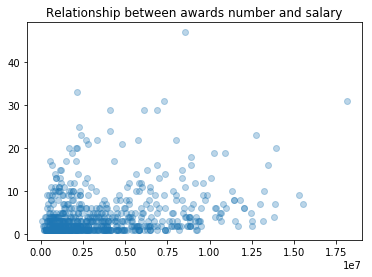

```python
plt.scatter(df_awards.salary,df_awards.awardID,alpha=0.3)
plt.title('Relationship between awards number and salary')
plt.show()
```

We see no obvious patterns between salary and number of awards.

#### salary and Allstars

```python
df_salaries['is_Allstar'] = df_salaries['playerID'].isin(Allstar.playerID)
df_salaries.head()
```

|  | playerID | salary | is_HOF | is_Allstar |
| --- | --- | --- | --- | --- |
| 0 | barkele01 | 870000 | False | True |
| 1 | bedrost01 | 550000 | True | True |
| 2 | benedbr01 | 545000 | False | True |
| 3 | campri01 | 633333 | False | False |
| 4 | ceronri01 | 625000 | False | False |

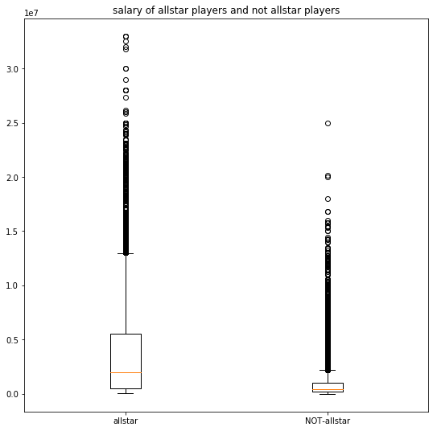

```python
collectn_5 = df_salaries.loc[df_salaries.is_Allstar==True, 'salary']
collectn_6 = df_salaries.loc[df_salaries.is_Allstar==False, 'salary']

data_to_plot3 = [collectn_5,collectn_6]
# Create a figure instance
fig = plt.figure(1,figsize=(9, 9))

# Create an axes instance
ax = fig.add_subplot(111)

# Create the boxplot
bp=ax.boxplot(data_to_plot3)
ax.set_xticklabels(['allstar', 'NOT-allstar'])
ax.set_title('salary of allstar players and not allstar players')
plt.show()
```

This figure show that all stars have higher salary than other people. Let's check that out by getting the statistics data.

```python
df_salaries.groupby('is_Allstar').describe()
```

| is_Allstar | salary count | salary mean | salary std | salary min | salary 25% | salary 50% | salary 75% | salary max |
| --- | --- | --- | --- | --- | --- | --- | --- | --- |
| False | 16898.0 | 1.058404e+06 | 1.724869e+06 | 0.0 | 210000.0 | 427500.0 | 1000000.0 | 25000000.0 |
| True | 9530.0 | 3.907054e+06 | 4.758901e+06 | 60000.0 | 513925.0 | 2000000.0 | 5500000.0 | 33000000.0 |

All star mean salary is 3.907054e+06 while not-allstar is 1.058404e+06.

## Conclutions

This report discusses two questions base on the baseball dataset.

To answer the second question, 4 different variables were used to find out if there are any patterns. Those are body data, Hall of frame data, all star data, awards data. Finally, the characteristics of baseball players with the highest salaries including high weight, Hall of frame member, and all-star player. But we still can not say that this is absolutely right, couse we just explore a small part of the data, and other situation as team and boss are not considered.